# Assignment3R

Benjamin Moran

1 September 2016

### Getting Started the Project

1. Open the page https://www.google.com.au/trends/.
2. Type a search keyword, say `wine’.
3. Choose a country, say `Australia’.
4. Choose a compare search keyword, say `beer’.
5. Save the data file with extension .csv’ on your computer, say test.csv’.
6. Rearrange your data file such that each column contains the heading and data only.
7. Set your current working directory in R where the le has been saved.

```r
setwd("/Users/benjamin/R/STAT3040/Assignments")
```

8. Store the data from the le to a variable in R:

```r
WBAust <- read.csv("GTWineBeerTs.csv", header=TRUE, skip = 1)
```

9. Look at the structure of the variable:

```
##     Month wine...Australia. beer...Australia.
## 1 2004-01                88                47
## 2 2004-02                95                43
## 3 2004-03                89                39
## 4 2004-04                95                42
## 5 2004-05                93                38
## 6 2004-06                97                40
```

10. All students should form groups of size 1-3 to carry out the project. The list of each group mem-bers should be sent to `Ali.Eshragh@newcastle.edu.au’ by Wednesday, September 7, 11:55pm.
11. Those students that do not join a group, should attend the consultation session in V239 on Thursday, September 8, 11:30am-12:30pm to discuss the possibility of forming new groups to-gether.
12. Each group should send their suggested data le with a short description to `Ali.Eshragh@newcastle.edu.au’ by Wednesday, October 5, 11:55pm. You are free to nd your dataset from any permitted re-

source. `Google-Trend’ is only one suggestion.

### Linear Regression in R

1. Find the time range of dataset:

```r
WBAust[1,1]
```

```
## [1] 2004-01
## 152 Levels: 2004-01 2004-02 2004-03 2004-04 2004-05 2004-06 ... 2016-08
```

```r
dim(WBAust)
```

```
## [1] 152   3
```

```r
WBAust[152,1]
```

```
## [1] 2016-08
## 152 Levels: 2004-01 2004-02 2004-03 2004-04 2004-05 2004-06 ... 2016-08
```

2. Construct two time series for wine and beer consumption in Australia within the range of ob-servation times:

```r
WineTS <- ts(WBAust[,2], start = c(2004,1), end = c(2016,8), frequency = 12)
WineTS
```

```
##      Jan Feb Mar Apr May Jun Jul Aug Sep Oct Nov Dec
## 2004  88  95  89  95  93  97  90  91  91  97  90 100
## 2005  87  91  91  89  93  93  89  87  86  90  83  97
## 2006  82  83  84  82  92  96  91  87  81  86  83  90
## 2007  75  79  80  80  83  84  80  75  72  77  75  85
## 2008  74  79  77  77  81  81  77  70  72  72  77  84
## 2009  71  74  74  75  81  85  85  76  73  77  77  84
## 2010  73  75  81  74  78  80  83  74  71  73  75  87
## 2011  69  75  72  71  77  77  80  73  70  71  73  85
## 2012  71  75  75  69  74  75  71  69  68  69  72  82
## 2013  67  73  72  70  73  79  74  73  67  69  73  83
## 2014  71  74  72  75  82  79  81  74  72  72  74  88
## 2015  74  76  74  76  80  82  83  80  75  76  79  94
## 2016  80  78  76  80  84  87  85  79
```

```r
BeerTS <- ts(WBAust[,3], start = c(2004,1), end = c(2016,8), frequency = 12)
BeerTS
```

```
##      Jan Feb Mar Apr May Jun Jul Aug Sep Oct Nov Dec
## 2004  47  43  39  42  38  40  38  38  43  46  43  45
## 2005  41  43  41  43  46  41  43  53  47  47  51  53
## 2006  47  47  47  42  44  38  39  40  44  44  43  52
## 2007  43  40  37  41  37  39  36  37  38  41  43  47
## 2008  37  36  37  35  36  35  34  34  37  40  41  45
## 2009  42  34  37  38  35  35  39  36  40  41  42  50
## 2010  42  39  35  38  36  38  38  37  38  41  42  54
## 2011  44  40  38  39  39  38  38  39  42  43  43  55
## 2012  47  42  39  42  47  40  38  39  43  42  43  53
## 2013  48  44  42  39  40  38  39  43  42  45  47  57
## 2014  53  44  42  43  45  41  43  44  46  48  49  57
## 2015  51  44  44  45  46  43  45  48  50  53  53  64
## 2016  56  50  50  49  48  46  47  45
```

```r
BeerTS2 <- fortify(BeerTS) %>%
  separate(Index, c("Year", "Month", "Day")) %>%
  subset(select = -Day)
```

3. Plot the time series of WineTS and BeerTS:

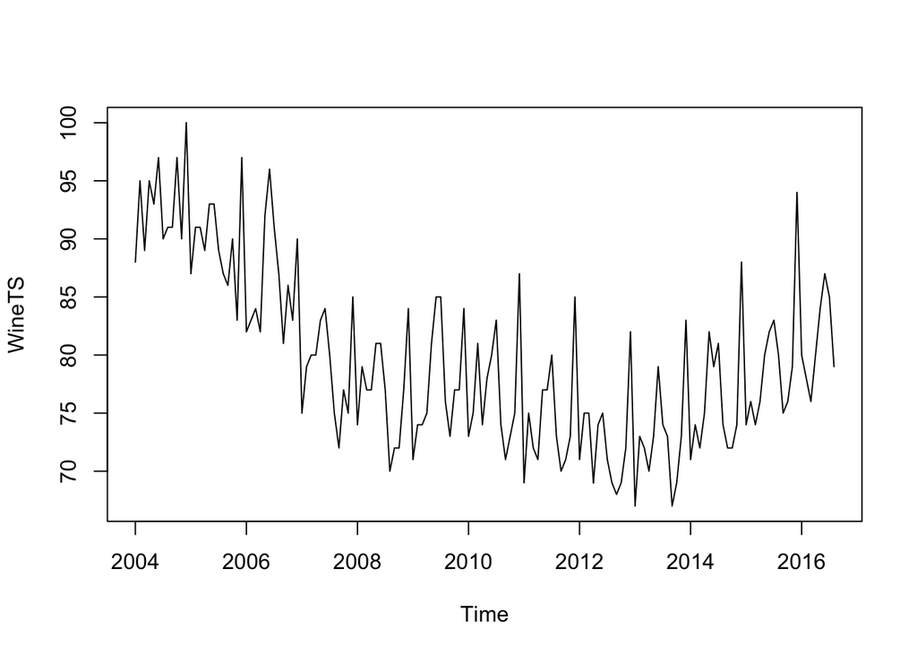

```r
plot.ts(WineTS, type="l")
```

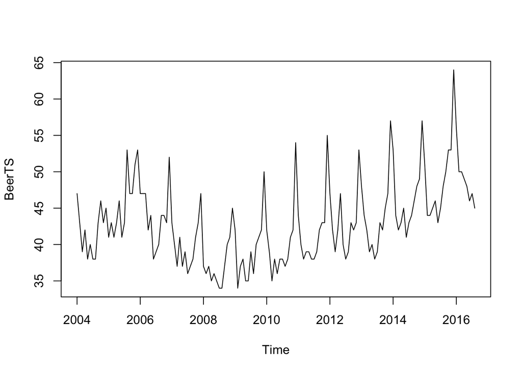

```r
plot.ts(BeerTS, type="l")
```

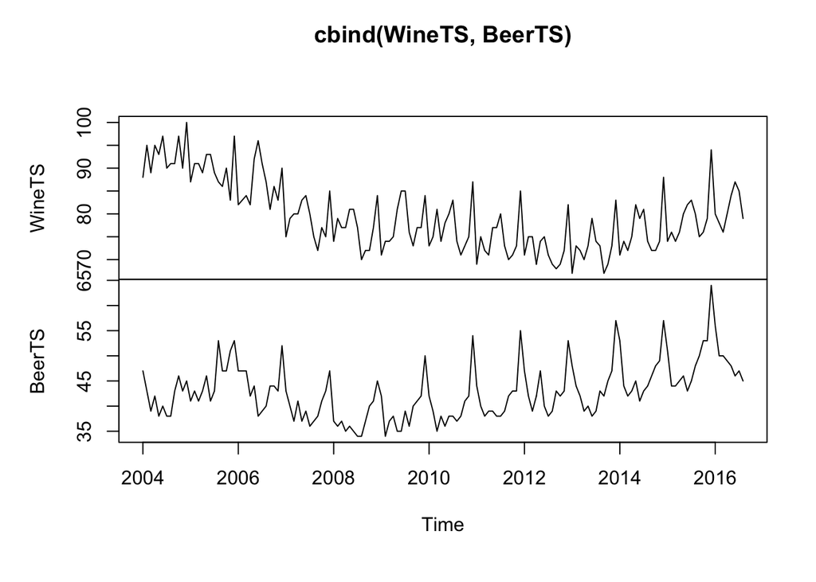

```r
plot.ts(cbind(WineTS, BeerTS), type="l")
```

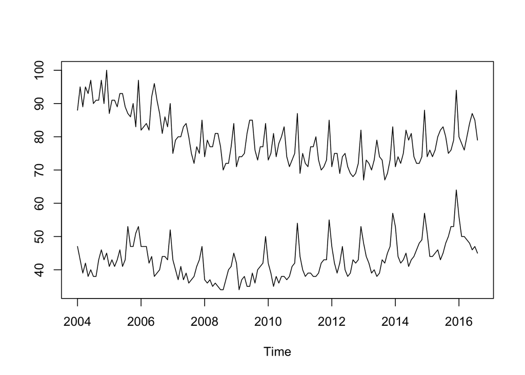

```r
ts.plot(cbind(WineTS, BeerTS), type="l")
```

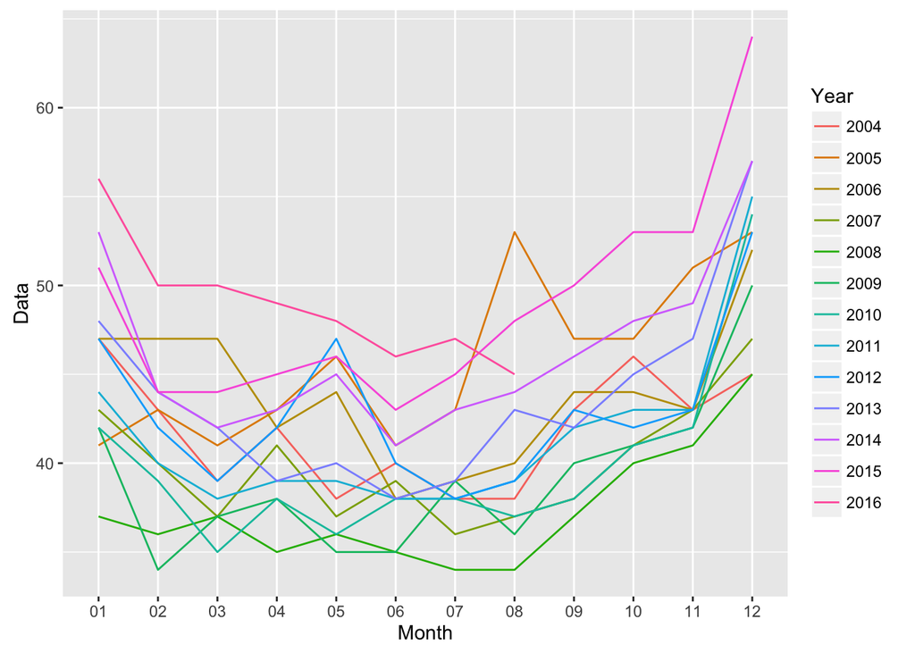

```r
ggplot(BeerTS2, aes(Month, Data, group = Year, colour = Year)) +
  geom_line()
```

4. Construct a time variable for observation times:

```r
TimeTS <- time(WineTS)
TimeTS
```

```
##           Jan      Feb      Mar      Apr      May      Jun      Jul
## 2004 2004.000 2004.083 2004.167 2004.250 2004.333 2004.417 2004.500
## 2005 2005.000 2005.083 2005.167 2005.250 2005.333 2005.417 2005.500
## 2006 2006.000 2006.083 2006.167 2006.250 2006.333 2006.417 2006.500
## 2007 2007.000 2007.083 2007.167 2007.250 2007.333 2007.417 2007.500
## 2008 2008.000 2008.083 2008.167 2008.250 2008.333 2008.417 2008.500
## 2009 2009.000 2009.083 2009.167 2009.250 2009.333 2009.417 2009.500
## 2010 2010.000 2010.083 2010.167 2010.250 2010.333 2010.417 2010.500
## 2011 2011.000 2011.083 2011.167 2011.250 2011.333 2011.417 2011.500
## 2012 2012.000 2012.083 2012.167 2012.250 2012.333 2012.417 2012.500
## 2013 2013.000 2013.083 2013.167 2013.250 2013.333 2013.417 2013.500
## 2014 2014.000 2014.083 2014.167 2014.250 2014.333 2014.417 2014.500
## 2015 2015.000 2015.083 2015.167 2015.250 2015.333 2015.417 2015.500
## 2016 2016.000 2016.083 2016.167 2016.250 2016.333 2016.417 2016.500
##           Aug      Sep      Oct      Nov      Dec
## 2004 2004.583 2004.667 2004.750 2004.833 2004.917
## 2005 2005.583 2005.667 2005.750 2005.833 2005.917
## 2006 2006.583 2006.667 2006.750 2006.833 2006.917
## 2007 2007.583 2007.667 2007.750 2007.833 2007.917
## 2008 2008.583 2008.667 2008.750 2008.833 2008.917
## 2009 2009.583 2009.667 2009.750 2009.833 2009.917
## 2010 2010.583 2010.667 2010.750 2010.833 2010.917
## 2011 2011.583 2011.667 2011.750 2011.833 2011.917
## 2012 2012.583 2012.667 2012.750 2012.833 2012.917
## 2013 2013.583 2013.667 2013.750 2013.833 2013.917
## 2014 2014.583 2014.667 2014.750 2014.833 2014.917
## 2015 2015.583 2015.667 2015.750 2015.833 2015.917
## 2016 2016.583
```

5. Plot the scatterplot matrix:

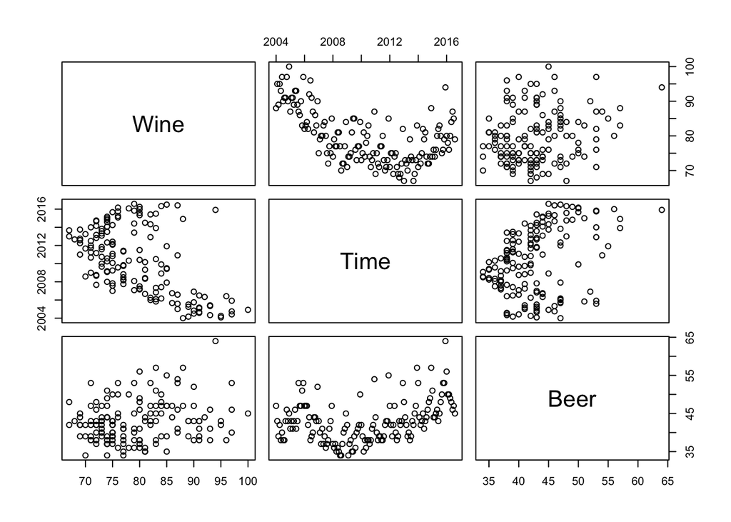

```r
data <- data.frame(Wine = WineTS, Time = TimeTS, Beer = BeerTS)
pairs(cbind(Wine = WineTS, Time = TimeTS, Beer = BeerTS))
```

6. Fit two regression models $\begin{cases} \begin{aligned} \text{Model 1: Wine}_{t} &= \beta_{1} + \beta_{2}t + \beta_{3}\text{beer}_{t} + \mathcal{W}_{t} \\ \text{Model 2: Wine}_{t} &= \beta_{1} + \beta_{2}t + \beta_{3}t^{2} + \beta_{4}\text{beer}_{t} + \mathcal{W}_{t} \end{aligned} \end{cases}$

```r
fit1 <- lm(WineTS ~ TimeTS + BeerTS)
TimeTS2 <- TimeTS^2
fit2 <- lm(WineTS ~ TimeTS + TimeTS2 + BeerTS)
```

7. Summary of the regression parameters estimations:

```r
glance(fit1)
```

```
##   r.squared adj.r.squared    sigma statistic      p.value df   logLik
## 1 0.4851104     0.4781991 5.470612  70.19121 3.331985e-22  3 -472.471
##       AIC      BIC deviance df.residual
## 1 952.942 965.0375 4459.212         149
```

```r
tidy(fit1)
```

```
##          term     estimate    std.error statistic      p.value
## 1 (Intercept) 2987.6336274 258.16015861  11.57279 1.683544e-22
## 2      TimeTS   -1.4598379   0.12903729 -11.31330 8.273391e-22
## 3      BeerTS    0.6216368   0.08686629   7.15625 3.499880e-11
```

```r
glance(fit2)
```

```
##   r.squared adj.r.squared    sigma statistic      p.value df    logLik
## 1 0.6530338     0.6460007 4.505933  92.85152 7.577188e-34  4 -442.4719
##        AIC      BIC deviance df.residual
## 1 894.9438 910.0632 3004.907         148
```

```r
tidy(fit2)
```

```
##          term      estimate    std.error statistic      p.value
## 1 (Intercept)  1.194059e+06 1.407328e+05  8.484582 2.063967e-14
## 2      TimeTS -1.186591e+03 1.400308e+02 -8.473785 2.196949e-14
## 3     TimeTS2  2.948075e-01 3.483338e-02  8.463363 2.333390e-14
## 4      BeerTS  2.906229e-01 8.154065e-02  3.564147 4.918091e-04
```

8. Compare the values of AIC for two models:

```r
AIC(fit1)/152 - log(2*pi)
```

```
## [1] 4.431478
```

```r
AIC(fit2)/152 - log(2*pi)
```

```
## [1] 4.049911
```

#### References

[1] R.H. Shumway and D.S. Sto er, Time Series Analysis and Its Applications With R Examples, Springer, New York, 2010.